# HW 6 Contrastive learning

This assignment aims to have you learn how to modify loss functions and simultaneously process multiple feature vectors in both face verification and face recognition tasks by using the CelebA dataset as an example.

CelebFaces Attributes Dataset (CelebA) is a large-scale face attributes dataset with more than 200K celebrity images, each with 40 attribute annotations, covering a wide range of pose variations and background clutter. The dataset is pruned so that the training time is appropriate for the assignment.

1. Face verification with contrastive loss
2. Face verification with triplet loss
3. Face verification with InfoNCE loss
4. Face verification evaluation

# Import main libraries

```python
import pandas as pd
import matplotlib.pyplot as plt
import numpy as np
import os
import os.path as osp
from collections import defaultdict
from PIL import Image
import math
from tqdm.notebook import tqdm
import random

import torch
from torch import nn
import torch.nn.functional as F
from torch import optim
import torchvision
from torch.utils.data import Dataset, DataLoader
from torchvision import transforms
```

```python
!pwd
```

```
/home/chatrin/Documents/Chat/CU/Year-3/2110573-Pattern-Recognition/assignment/hw6
```

# Download and unzip the dataset

```python
# !pip install gdown
```

```python
# !gdown --id 1_2oATmA0Jw61qs7I7kAG9Q2LHNZSQX7A
```

```python
# !unzip content/large_prepared_data.zip
```

# Common dataset

```python
class FaceDataset(Dataset):
    def __init__(self, root_dir, transform=None):
        self.root_dir = root_dir
        self.transform = transform
        self.label_df = pd.read_csv(f"{self.root_dir}/label_df.csv")

    def __len__(self):
        return len(self.label_df)

    def __getitem__(self, idx):
        data = self.label_df.iloc[idx]
        img = Image.open(f"{self.root_dir}/{data['filename']}").convert("RGB")
        if self.transform is not None:
            transformed_img = self.transform(img)
        else:
            transformed_img = None
        identity = data["identity"]
        return transformed_img, identity, np.array(img)
```

This is an example to display a face image with its identity

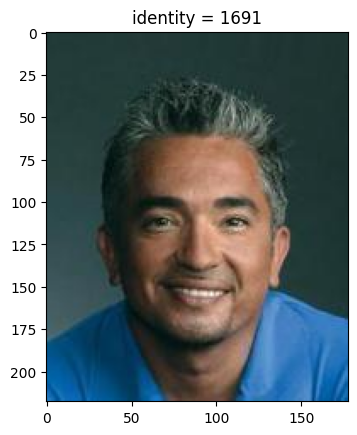

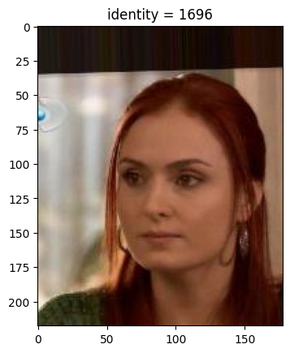

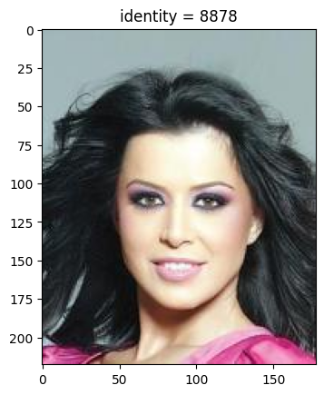

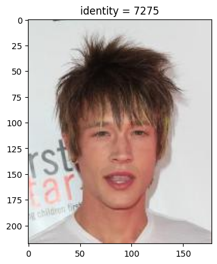

```python
import matplotlib.pyplot as plt

face_dataset = FaceDataset(root_dir="large_prepared_data/test")

for idx in range(4):
    _, identity, img = face_dataset[idx]
    plt.title(f"identity = {identity}")
    plt.imshow(img)
    plt.show()
```

# Part 1: Face verification with contrastive loss

The objective of the face verification task is to validate whether the face image $x$ has the identity $y$ by comparing it to the face database of the claimed identity. If the face similarity score between $x$ and the face in the database of $y$ is above a certain threshold, the image is then verified; otherwise, the identity is rejected.

In HW3, you have learned to calculate a similarity score based on compact image representation using a PCA / Fisher projection. Therefore, in this part, you will instead implement a more contemporary method by training the NN to propose a compact representation (feature vector) by using a Siamese network and contrastive loss (Chopra et al., 2005, https://ieeexplore.ieee.org/stamp/stamp.jsp?tp=&arnumber=1467314).

In contrast to the classification task that forces the model to learn all possible classes of objects, the general idea of object verification is based on contrastive learning, a framework that teaches the model to distinguish the two objects from each other. For a contrastive loss, the model will receive a pair of image and then learn to recognize whether both of them has the same identity by encouraging the feature vector of the same identity to come closer and different one to move away from each other.

## 1.1 (TODO) Dataset and DataLoader

First, we will start by writing a dataloader. The contrastive loss learns whether a pair of images have the same identity. Therefore, in this subsection, you have to write a dataloader that returns the tuple `(img1, img2, is_same_identity (bool))`.

**File structure of this dataset**

```
- large_prepared_data/
└───train/
|    - {img1}.jpg
|    - {img2}.jpg
|    - label_df.csv
└───val/
|    - {img3}.jpg
|    - {img4}.jpg
|    - label_df.csv
└───test/
    - {img5}.jpg
    - {img6}.jpg
    - label_df.csv
```

**Note**

label_df.csv has 2 columns that are the filename such as 001257.jpg and the identity such as 1691

**Instructions**

TODO 1-4: Fill in the missing code in the cells below.  
TODO 1-2: Organize the dataset for simple data access.  
TODO 3: Randomly select the datapoint from the dataset and format it to be ready for training.  
TODO 4: Initialize the dataloader.

```python
class SiameseDataset(Dataset):
    def __init__(self, root_dir, transform=None):
        """
        The dataset of siamese network
        [Args]
        - root_dir = root directory of the dataset
        - transform = transformations for images
        """
        np.random.seed(123)
        random.seed(123)
        self.root_dir = root_dir
        self.transform = transform
        label_df = pd.read_csv(f"{root_dir}/label_df.csv")
        self.num_images = len(label_df)
        label_df = (
            label_df.groupby("identity")["filename"]
            .apply(list)
            .reset_index()
            .rename({"filename": "filenames"}, axis=1)
        )
        self.load_images_to_memory_(label_df)

    def load_images_to_memory_(self, label_df):
        """
        Load all images into memory
        [Args]
        - label_df = The dataframe containing the identities and the filenames of images
        """
        # TODO 1: load images to `self.data` according to the below structure
        # and `self.images`, `self.identities` following by idx
        # Note: identity{i}: str, image{i}: PIL.Image (convert them to RGB as well)
        # e.g. self.data = {
        #   'identity1': [image1, image2],
        #   'identity2': [image3, image4, image5],
        # }
        #
        # identity{i}: str, image{i}: PIL.Image
        self.data = {}
        self.img = {}
        self.identities = {}
        for idx in tqdm(range(len(label_df)), desc="Loading images to memory"):
            row = label_df.iloc[idx]
            identity, filenames = row["identity"], row["filenames"]

            self.data[identity] = [
                Image.open(f"{self.root_dir}/{filename}").convert("RGB")
                for filename in filenames
            ]
            self.img[identity] = [self.transform(img) for img in self.data[identity]]
            self.identities[idx] = identity

        # TODO 2: keep all unique identities as list with `self.unique_identities`
        # in `self.unique_identities` as a numpy array.
        self.unique_identities = np.array(list(self.data.keys()))

    def __len__(self):
        return self.num_images

    def __getitem__(self, idx):
        """
        Return a pair of image together with its label
        [Args]
        - idx: int
        [Return]
        - img1: torch.FloatTensor
        - img2: torch.FloatTensor
        - label: torch.FloatTensor = 1 (same class), 0 (different class)
        """
        # TODO 3: randomly sample a pair of images
        # Note: idx is even, it should return the same class pair and otherwise
        # Please use label = 1 for the same class pair
        # and label = 0 for the different class pair
        unique_identities_list = list(self.unique_identities)
        if idx % 2 == 0:
            # Same class pair
            identity = random.choice(unique_identities_list)
            images = self.data[identity]
            img1, img2 = random.sample(images, 2)
            label = 1
        else:
            # Different class pair
            identity1, identity2 = random.sample(unique_identities_list, 2)
            while identity1 == identity2:
                identity1, identity2 = random.sample(unique_identities_list, 2)
            img1 = random.choice(self.data[identity1])
            img2 = random.choice(self.data[identity2])
            label = 0
        if self.transform is not None:
            img1 = self.transform(img1)
            img2 = self.transform(img2)

        return img1, img2, torch.from_numpy(np.array([label], dtype=np.float32))
```

```python
img_size = 224
train_transform = transforms.Compose(
    [
        transforms.Resize((256, 256)),
        transforms.CenterCrop(img_size),
        transforms.RandomHorizontalFlip(p=0.5),
        transforms.ToTensor(),
        transforms.Normalize(
            mean=[0.5319, 0.4399, 0.3929], std=[0.3076, 0.2898, 0.2907]
        ),
    ]
)

val_transform = transforms.Compose(
    [
        transforms.Resize((256, 256)),
        transforms.CenterCrop(img_size),
        transforms.ToTensor(),
        transforms.Normalize(
            mean=[0.5319, 0.4399, 0.3929], std=[0.3076, 0.2898, 0.2907]
        ),
    ]
)

train_batch_size = 16
val_batch_size = 16
test_batch_size = 16


# TODO 4: declare the datasets and the dataloaders
train_siamese_dataset = SiameseDataset(
    root_dir="large_prepared_data/train", transform=train_transform
)
train_siamese_dataloader = DataLoader(
    train_siamese_dataset, batch_size=train_batch_size, shuffle=True
)

val_siamese_dataset = SiameseDataset(
    root_dir="large_prepared_data/val", transform=val_transform
)
val_siamese_dataloader = DataLoader(
    val_siamese_dataset, batch_size=val_batch_size, shuffle=False
)

test_siamese_dataset = SiameseDataset(
    root_dir="large_prepared_data/test", transform=val_transform
)
test_siamese_dataloader = DataLoader(
    test_siamese_dataset, batch_size=test_batch_size, shuffle=False
)
```

## 1.2 (TODO) Siamese network

After the dataloader is initialized, we then build a siamese network. Section 1.5 will explain how a siamese network works in full detail.

Siamese network is a typical CNN that consists of three modules:

1. A feature extractor (ResNet18) for extracting the feature map from an image.
2. A global pooling for reducing the image dimension.
3. A fully connected layer for compressing the feature vector

Every fully connected layer is followed by ReLU activations.

TODO 5: Implement a siamese network based on the description.

**Note**

1. You can use the ResNet18 from the `torchvision` library (How to use torchvision: https://pytorch.org/vision/stable/models.html)
2. We will not use pretrained weights.

Figure 1 Siamese network

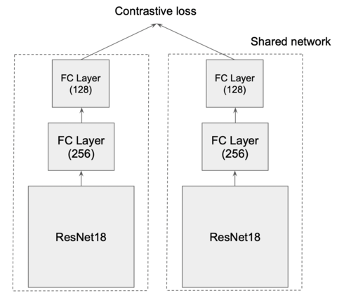

```python
from torchvision import models
```

```python
class SiameseNetwork(nn.Module):
    # TODO 5: implement the siamese network
    def __init__(self):
        super().__init__()
        self.resnet18 = models.resnet18(weights=None)

        self.pool = nn.AdaptiveAvgPool1d(512)
        self.fc1 = nn.Linear(512, 256)
        self.fc2 = nn.Linear(256, 128)

    def extract_feature(self, x):
        x = self.resnet18(x)
        x = self.pool(x)
        x = F.relu(self.fc1(x))
        output = F.relu(self.fc2(x))
        return output

    def forward(self, input1, input2):
        feat1 = self.extract_feature(input1)
        feat2 = self.extract_feature(input2)
        return feat1, feat2
```

## 1.3 (TODO) Constrastive loss

A contrastive loss is a loss used to minimize the dissimilarity between two images by encouraging the feature vector of the same identity to come closer and different one further than a constant margin $m$ to move away from each other.

The contrastive loss is mathematically defined as:

$ L\ (contrastive\ loss ) = \begin{cases} d(r_1, r_2) & if\ identity(r1) = identity(r2) \\ max(0, m - d(r_1, r_2)) & if\ identity(r1) \neq identity(r2) \\ \end{cases} \ $

where

- $d(r_1, r_2)$ = euclidean distance between $r_1$ and $r_2$
- $m$ = margin
- $identity(x)$ = the identity of x
- $r_1$ = the feature vector of the first image
- $r_2$ = the feature vector of the second image

The term $d(r_1, r_2)$ is the distance between the two feature vectors. The contrastive loss minimizes the distance between the feature vectors of the same identity (positive pair) but maximizes the distance of the different identities (negative pair).

The margin $m$ is used to prevent the loss from collapsing to a trivial solution. For instance, when $m = 0$, the model could achieve $L = 0$ just by exploiting the objective by setting $r_1 = r_2$, and the model, as a result, would learn nothing useful.

**HINT**

Many torch functions often have the same functionality as NumPy functions, even sharing the same function name. Therefore, if you are struggling with this part, you might write the loss using NumPy first and then convert it to the torch function (https://pytorch.org/docs/stable/torch.html) later. **Avoid using "if statements" to make the training faster. You have already learned many tricks that convert if statements into a single equation.**

TODO 6: Implement a contrastive loss based on the description above.

```python
import torch
from torch import nn
import torch.nn.functional as F

class ContrastiveLoss(torch.nn.Module):
    # TODO 6: implement the contrastive loss
    def __init__(self, margin):
        super().__init__()
        self.margin = margin

    def forward(self, output1, output2, label):
        # Calculate Euclidean distance
        distance = F.pairwise_distance(output1, output2, keepdim=True)

        # When label == 1 (same identity), we minimize the distance
        # When label == 0 (different identity), we maximize distance up to the margin
        # We square the terms which is the standard Hadsell Contrastive Loss formulation
        loss_contrastive = torch.mean(
            label * distance +
            (1 - label) * torch.clamp(self.margin - distance, min=0.0)
        )

        return loss_contrastive
```

## 1.4 Initiazing the model, criterion, optimizer and scheduler

```python
siamese_margin = 2
learning_rate = 1e-4

siamese_model = SiameseNetwork()
siamese_criterion = ContrastiveLoss(margin=siamese_margin)
siamese_optimizer = optim.Adam(siamese_model.parameters(), lr=learning_rate)
siamese_scheduler = optim.lr_scheduler.ReduceLROnPlateau(
    siamese_optimizer, "min", patience=5, factor=0.1, min_lr=1e-8
)
```

## 1.5 (TODO) Training loop

The training procedure of a siamese network consists of the following steps:

1. Forward pass the `img1`.
2. Forward pass the `img2`.
3. Calculate the distance between the feature vector of `img1` and `img2` $(d(r_1, r_2))$.
4. Use the distance in step 3 as a loss and update the model.
5. Repeat step 1-4 until satisfied.

As you would notice, both first and second step shares the same network weights. Therefore, the word "Siamese" in the siamese network originates from the "Siamese twins" since the network performs two forward passes to compare whether the feature vectors have the same identity by using the same set of network parameters (shared parameters).

TODO 7-8: Feed pairs of images to the network, compute contrastive loss to measure the dissimilarity of pairs of face images and update the network.

TODO 9: Feed a pair of images from validation set to the network and compute the validation loss.

**Trivia**

The Siamese twin is a conjoined twin brother born in Siam who later move to the US (https://th.wikipedia.org/wiki/%E0%B8%AD%E0%B8%B4%E0%B8%99-%E0%B8%88%E0%B8%B1%E0%B8%99).

```python
num_epochs = 20
device = "cuda" if torch.cuda.is_available() else "cpu"
siamese_model.to(device)

os.makedirs("weights", exist_ok=True)
best_weights_path = "weights/best_siamese_weights.pth"

train_losses = []
val_losses = []
min_val_loss = float("inf")

for epoch in tqdm(range(num_epochs)):
    siamese_model.train()
    total_train_loss = 0

    for img1, img2, label in tqdm(train_siamese_dataloader):

        # Move tensors to the configured device
        img1, img2, label = img1.to(device), img2.to(device), label.to(device)

        # TODO 7: feed data to model and compute loss
        siamese_optimizer.zero_grad()

        feat1, feat2 = siamese_model(img1, img2)
        train_loss = siamese_criterion(feat1, feat2, label)

        # TODO 8: back propagate
        train_loss.backward()
        siamese_optimizer.step()

        total_train_loss += train_loss.item()

    current_train_loss = total_train_loss / len(train_siamese_dataloader)
    train_losses.append(current_train_loss)

    total_val_loss = 0
    siamese_model.eval()

    # Validation shouldn't track gradients
    with torch.no_grad():
        for val_img1, val_img2, val_label in val_siamese_dataloader:

            # Move tensors to the configured device
            val_img1, val_img2, val_label = val_img1.to(device), val_img2.to(device), val_label.to(device)

            # TODO 9: feed data to model and compute loss
            val_feat1, val_feat2 = siamese_model(val_img1, val_img2)
            val_loss = siamese_criterion(val_feat1, val_feat2, val_label)

            total_val_loss += val_loss.item()

    current_val_loss = total_val_loss / len(val_siamese_dataloader)
    val_losses.append(current_val_loss)
    if current_val_loss < min_val_loss:
        min_val_loss = current_val_loss
        torch.save(siamese_model.state_dict(), best_weights_path)
    print(
        f'Epoch {epoch+1} - Train loss = {current_train_loss:.4f} - Val loss = {current_val_loss:.4f} - best min_val_loss = {min_val_loss:.4f} - lr = {siamese_optimizer.param_groups[0]["lr"]:.8f}'
    )
    siamese_scheduler.step(current_val_loss)
```

[output not shown]

```
Epoch 2 - Train loss = 0.7117 - Val loss = 0.6684 - best min_val_loss = 0.6684 - lr = 0.00001000
```

```
Epoch 3 - Train loss = 0.7348 - Val loss = 0.7584 - best min_val_loss = 0.6684 - lr = 0.00001000
```

```
Epoch 4 - Train loss = 0.7181 - Val loss = 0.6790 - best min_val_loss = 0.6684 - lr = 0.00001000
```

```
Epoch 5 - Train loss = 0.7115 - Val loss = 0.7281 - best min_val_loss = 0.6684 - lr = 0.00000100
```

```
Epoch 6 - Train loss = 0.6991 - Val loss = 0.6793 - best min_val_loss = 0.6684 - lr = 0.00000100
```

```
Epoch 7 - Train loss = 0.7420 - Val loss = 0.6845 - best min_val_loss = 0.6684 - lr = 0.00000100
```

```
Epoch 8 - Train loss = 0.7376 - Val loss = 0.7809 - best min_val_loss = 0.6684 - lr = 0.00000100
```

```
Epoch 9 - Train loss = 0.7330 - Val loss = 0.6451 - best min_val_loss = 0.6451 - lr = 0.00000100
```

```
Epoch 10 - Train loss = 0.6963 - Val loss = 0.7258 - best min_val_loss = 0.6451 - lr = 0.00000100
```

```
Epoch 11 - Train loss = 0.7164 - Val loss = 0.7058 - best min_val_loss = 0.6451 - lr = 0.00000010
```

```
Epoch 12 - Train loss = 0.7094 - Val loss = 0.6876 - best min_val_loss = 0.6451 - lr = 0.00000010
```

```
Epoch 13 - Train loss = 0.7270 - Val loss = 0.6604 - best min_val_loss = 0.6451 - lr = 0.00000010
```

```
Epoch 14 - Train loss = 0.7065 - Val loss = 0.6939 - best min_val_loss = 0.6451 - lr = 0.00000010
```

```
Epoch 15 - Train loss = 0.7285 - Val loss = 0.6739 - best min_val_loss = 0.6451 - lr = 0.00000010
```

```
Epoch 16 - Train loss = 0.7568 - Val loss = 0.6330 - best min_val_loss = 0.6330 - lr = 0.00000010
```

```
Epoch 17 - Train loss = 0.7243 - Val loss = 0.7181 - best min_val_loss = 0.6330 - lr = 0.00000001
```

```
Epoch 18 - Train loss = 0.7458 - Val loss = 0.7471 - best min_val_loss = 0.6330 - lr = 0.00000001
```

```
Epoch 19 - Train loss = 0.7198 - Val loss = 0.6545 - best min_val_loss = 0.6330 - lr = 0.00000001
```

```
Epoch 20 - Train loss = 0.7400 - Val loss = 0.7239 - best min_val_loss = 0.6330 - lr = 0.00000001
```

## 1.6 Visualization

This visualization displays pairs of images together with the distance between those pairs.

```
Clipping input data to the valid range for imshow with RGB data ([0..1] for floats or [0..255] for integers). Got range [0.0..1.1742941].
```

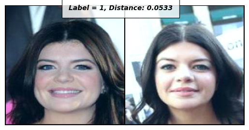

```
Clipping input data to the valid range for imshow with RGB data ([0..1] for floats or [0..255] for integers). Got range [0.0..1.1742941].
```

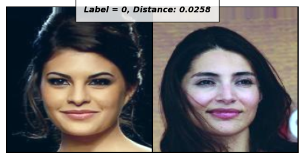

```
Clipping input data to the valid range for imshow with RGB data ([0..1] for floats or [0..255] for integers). Got range [0.0..1.1701446].
```

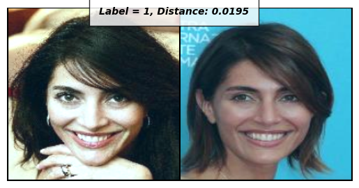

```
Clipping input data to the valid range for imshow with RGB data ([0..1] for floats or [0..255] for integers). Got range [0.0..1.1742941].
```

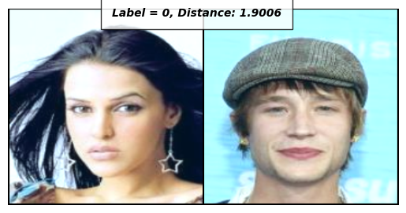

```
Clipping input data to the valid range for imshow with RGB data ([0..1] for floats or [0..255] for integers). Got range [0.0..1.1742941].
```

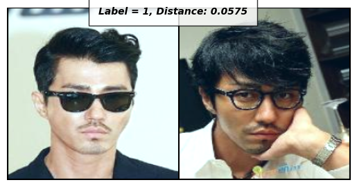

```
Clipping input data to the valid range for imshow with RGB data ([0..1] for floats or [0..255] for integers). Got range [0.0..1.1742941].
```

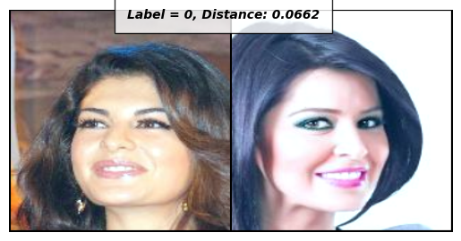

```
Clipping input data to the valid range for imshow with RGB data ([0..1] for floats or [0..255] for integers). Got range [0.0..1.1701446].
```

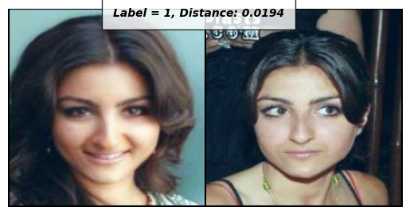

```
Clipping input data to the valid range for imshow with RGB data ([0..1] for floats or [0..255] for integers). Got range [0.0..1.083004].
```

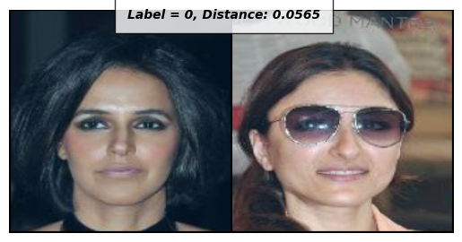

```
Clipping input data to the valid range for imshow with RGB data ([0..1] for floats or [0..255] for integers). Got range [0.0..1.1742941].
```

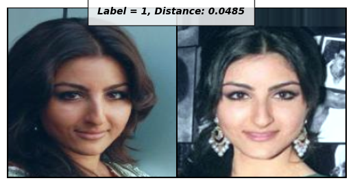

```
Clipping input data to the valid range for imshow with RGB data ([0..1] for floats or [0..255] for integers). Got range [0.0..1.0747049].
```

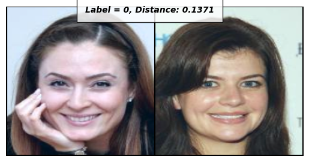

```
Clipping input data to the valid range for imshow with RGB data ([0..1] for floats or [0..255] for integers). Got range [0.0..1.1742941].
```

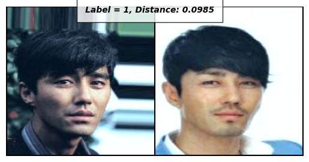

```
Clipping input data to the valid range for imshow with RGB data ([0..1] for floats or [0..255] for integers). Got range [0.0..1.1742941].
```

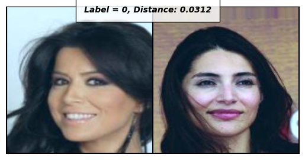

```
Clipping input data to the valid range for imshow with RGB data ([0..1] for floats or [0..255] for integers). Got range [0.0..1.1742941].
```

[4 more figures not shown]

```python
# Showing images
def imshow(img, text=None):
    npimg = img.numpy()
    plt.axis("off")
    if text:
        plt.text(
            120,
            8,
            text,
            style="italic",
            fontweight="bold",
            bbox={"facecolor": "white", "alpha": 0.8, "pad": 10},
        )

    plt.imshow(np.transpose(npimg, (1, 2, 0)))
    plt.show()


siamese_model.load_state_dict(torch.load(best_weights_path))
siamese_model.eval()

test_img1s, test_img2s, test_labels = next(iter(test_siamese_dataloader))
test_img1s, test_img2s, test_labels = (
    test_img1s.to(device),
    test_img2s.to(device),
    test_labels.to(device),
)
with torch.no_grad():
    test_out1s, test_out2s = siamese_model(test_img1s, test_img2s)


class UnNormalize(object):
    def __init__(self, mean, std):
        self.mean = mean
        self.std = std

    def __call__(self, tensor):
        """
        Args:
            tensor (Tensor): Tensor image of size (C, H, W) to be normalized.
        Returns:
            Tensor: Normalized image.
        """
        for t, m, s in zip(tensor, self.mean, self.std):
            t.mul_(s).add_(m)
            # The normalize code -> t.sub_(m).div_(s)
        return tensor


unnormalizer = UnNormalize(mean=[0.5319, 0.4399, 0.3929], std=[0.3076, 0.2898, 0.2907])

for test_out1, test_out2, test_img1, test_img2, test_label in zip(
    test_out1s, test_out2s, test_img1s, test_img2s, test_labels
):
    test_img1 = unnormalizer(test_img1.detach().cpu().unsqueeze(0))
    test_img2 = unnormalizer(test_img2.detach().cpu().unsqueeze(0))
    concatenated = torch.cat((test_img1, test_img2), 0)
    distance = F.pairwise_distance(test_out1.unsqueeze(0), test_out2.unsqueeze(0))
    imshow(
        torchvision.utils.make_grid(concatenated),
        f"Label = {int(test_label[0])}, Distance: {distance.item():.4f}",
    )
```

## 1.7 Plot loss history

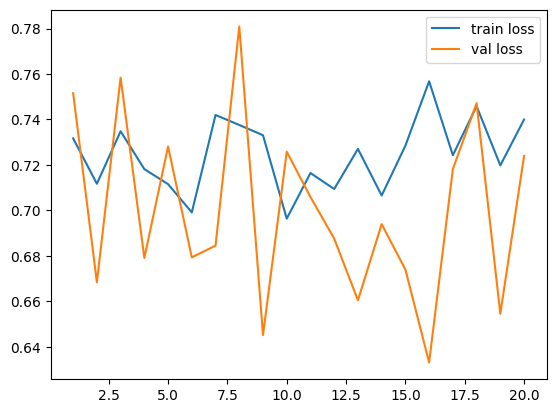

```python
plt.plot(np.arange(1, len(train_losses) + 1), train_losses, label="train loss")
plt.plot(np.arange(1, len(val_losses) + 1), val_losses, label="val loss")
plt.legend()
plt.show()
```

## 1.8 (TODO) Plot t-SNE

After the training process is finished, we evaluate whether the learned representation is informative. In this task, embedding visualization is often performed to verify that the feature learned by the network is behaving as intended, i.e., feature vectors of the same identity should be close to each other and far away from other identities. Since the feature vector dimension is too high for a human to interpret, therefore, in this assignment, we use the t-SNE dimensionality reduction technique to compress the feature into a 2D space.

**Instructions**

TODO 10: Extract the feature vectors of the test set and store them as

`embeddings`: torch.FloatTensor = feature vectors of all images in the test set

`identities`: list or torch.Tensor or np.array = identities of all images in the test set

**Hint**  
Use `FaceDataset` that is imported at `Common Dataset` section

**WARNING!!** Don't forget load its best weights and change to eval mode first

```python
test_batch_size = 32

# TODO 10: Extract the feature vectors of the test set and store them as
# `embeddings`: torch.FloatTensor = feature vectors of all images in the test set
# `identities`: list or torch.Tensor or np.array = identities of all images in the test set
# Hint      => Use `FaceDataset` that is imported at `Common Dataset` section
# WARNING!! => Don't forget load its best weights and change to eval mode first

test_dataset = FaceDataset(root_dir="large_prepared_data/test", transform=val_transform)
test_loader = DataLoader(test_dataset, batch_size=test_batch_size)

siamese_model.load_state_dict(torch.load('weights/best_siamese_weights.pth', map_location=device))
siamese_model.eval()

all_embeddings = []
all_identities = []

with torch.no_grad():
    for transformed_img, identity, _ in tqdm(test_loader):
        # Move images to GPU/CPU
        transformed_img = transformed_img.to(device)

        # 3. FORWARD PASS: This converts [32, 3, 224, 224] -> [32, 128]
        features = siamese_model.extract_feature(transformed_img)

        # Store as CPU tensors or numpy
        all_embeddings.append(features.cpu())

        # Identity might be a tensor or list depending on your Dataset
        if torch.is_tensor(identity):
            all_identities.append(identity.cpu())
        else:
            all_identities.extend(identity)

embeddings = torch.cat(all_embeddings)
if torch.is_tensor(all_identities[0]):
    identities = torch.cat(all_identities)
else:
    identities = all_identities
```

```python
import time
from sklearn.manifold import TSNE

time_start = time.time()
tsne = TSNE(n_components=2, verbose=1, perplexity=30, max_iter=3000)
tsne_result = tsne.fit_transform(embeddings, identities)
print("t-SNE done! Time elapsed: {} seconds".format(time.time() - time_start))
```

```
[t-SNE] Computing 91 nearest neighbors...
[t-SNE] Indexed 301 samples in 0.000s...
[t-SNE] Computed neighbors for 301 samples in 0.095s...
[t-SNE] Computed conditional probabilities for sample 301 / 301
[t-SNE] Mean sigma: 0.013540
[t-SNE] KL divergence after 250 iterations with early exaggeration: 48.696156
[t-SNE] KL divergence after 1800 iterations: 0.289660
t-SNE done! Time elapsed: 0.8387479782104492 seconds
```

```python
import plotly.express as px

# relabel to be easier to see in t-SNE visualization
label = []
idx = 0
id2label = dict()
for identity in identities:
    identity = int(identity)
    if identity not in id2label:
        id2label[identity] = idx
        idx += 1
    label.append(id2label[identity])

df_subset = pd.DataFrame({"label": label})

df_subset["tsne-2d-one"] = tsne_result[:, 0]
df_subset["tsne-2d-two"] = tsne_result[:, 1]

fig = px.scatter(
    df_subset, x="tsne-2d-one", y="tsne-2d-two", color="label", height=1000, width=1000
)
fig.show()
```

## 1.9 (TODO) Analyzing feature vector visualization result

TODO 11: What could you say about the displayed visualization? Is the model working as expected?

Answer here: No there is no obvious cluster from tsne visualization.

# Part 2: Face verification with triplet loss + center loss

In contrast to contrastive loss which learns to distinguish whether the two images have the same identity, triplet loss is proposed as an alternative by introducing an anchor image as a third input. Triplet loss receives three inputs: anchor, positive pair, and negative pair. The positive pair is an image having the same identity as the anchor while the negative pair is the one with a different identity. The loss learns to minimize the distance between the anchor and positive pair, and maximize the distance between the anchor and the negative pair. Compared to contrastive loss, triplet loss offers more training stability and better model performance.

Nevertheless, both contrastive and triplet loss also has some shortcomings as these losses only optimize on a pairwise level. This might result in feature vectors of the same identity taking the form of multiple small clusters scattering across the feature space since there is no explicit loss to bind them into a single group. Therefore, a center loss is proposed to mitigate this problem by encouraging the intra-class (same identity) feature vectors to come closer to their intra-class centroids.

In this part, you are going to implement a face verification network by jointly training **three losses**: triplet, center, and cross-entropy loss.

## 2.1 Dataset and DataLoader

In this section, you are going to implement a dataloader for the combined loss. The dataloader should return the tuple `(anchor_img, pos_img, neg_img, anchor_label, pos_label, neg_label)`.

- The positive image must have the same identity as the anchor image.
- The negative image must have a different identity from the anchor image.

```python
class TripletDataset(Dataset):
    def __init__(self, root_dir, transform=None):
        np.random.seed(123)
        random.seed(123)
        self.root_dir = root_dir
        self.transform = transform

        label_df = pd.read_csv(f"{root_dir}/label_df.csv")
        label_df = (
            label_df.groupby("identity")["filename"]
            .apply(list)
            .reset_index()
            .rename({"filename": "filenames"}, axis=1)
        )
        self.images = []
        self.labels = []
        self.label2indices = dict()
        self.load_images_to_memory_(label_df)

    def load_images_to_memory_(self, label_df):
        # load images and labels into memory
        # We have to relabel from identities to 0,1,2,...,num_classes-1
        # Relevant variables
        # 1. `self.images` = PIL images  (Also convert it to RGB)
        # 2. `self.label2indices` = the dictionary storing a label as a key and the indices of images as value
        # 3. `self.labels` = labels of images (relabeled)
        # Note: the index of images is from iterating over label_df
        self.images = []
        self.label2indices = defaultdict(list)
        self.labels = []
        img_idx = 0
        label_idx = 0
        identity2label = dict()
        for idx in tqdm(range(len(label_df))):
            row = label_df.iloc[idx]
            identity, filenames = row["identity"], row["filenames"]

            if identity not in identity2label:
                identity2label[identity] = label_idx
                label_idx += 1

            label = identity2label[identity]

            for filename in filenames:
                self.images.append(
                    Image.open(f"{self.root_dir}/{filename}").convert("RGB")
                )
                self.labels.append(label)
                self.label2indices[label].append(img_idx)
                img_idx += 1

    def __len__(self):
        return len(self.images)

    def __getitem__(self, idx):
        # generate an anchor image, a positive image and a negative image together with anchor_label
        # anchor image is the image according to idx
        # positive image is the image that has the same identity with the anchor image
        # negative image is the image that has the different identity with the anchor image
        anchor_img = self.images[idx]
        anchor_label = self.labels[idx]

        pos_idx = random.choice(self.label2indices[anchor_label])
        while pos_idx == idx:
            pos_idx = random.choice(self.label2indices[anchor_label])
        pos_img = self.images[pos_idx]
        pos_label = anchor_label
        neg_label = random.choice(list(set(self.labels) - {anchor_label}))
        neg_img = self.images[random.choice(self.label2indices[neg_label])]

        # utilize `self.transform' to convert images to tensors
        if self.transform is not None:
            anchor_img = self.transform(anchor_img)
            pos_img = self.transform(pos_img)
            neg_img = self.transform(neg_img)

        return anchor_img, pos_img, neg_img, anchor_label, pos_label, neg_label
```

```python
image_size = 224
train_transform = transforms.Compose(
    [
        transforms.Resize((256, 256)),
        transforms.CenterCrop(image_size),
        transforms.RandomHorizontalFlip(p=0.5),
        transforms.ToTensor(),
        transforms.Normalize(
            mean=[0.5319, 0.4399, 0.3929], std=[0.3076, 0.2898, 0.2907]
        ),
    ]
)

val_transform = transforms.Compose(
    [
        transforms.Resize((256, 256)),
        transforms.CenterCrop(image_size),
        transforms.ToTensor(),
        transforms.Normalize(
            mean=[0.5319, 0.4399, 0.3929], std=[0.3076, 0.2898, 0.2907]
        ),
    ]
)

train_batch_size = 16
val_batch_size = 16
test_batch_size = 16

# declare the datasets and the dataloaders

train_triplet_dataset = TripletDataset(
    root_dir="large_prepared_data/train", transform=train_transform
)
train_triplet_dataloader = DataLoader(
    train_triplet_dataset, batch_size=train_batch_size, shuffle=True, num_workers=2
)

val_triplet_dataset = TripletDataset(
    root_dir="large_prepared_data/val", transform=val_transform
)
val_triplet_dataloader = DataLoader(
    val_triplet_dataset, batch_size=val_batch_size, shuffle=False, num_workers=2
)

test_triplet_dataset = TripletDataset(
    root_dir="large_prepared_data/test", transform=val_transform
)
test_triplet_dataloader = DataLoader(
    test_triplet_dataset, batch_size=test_batch_size, shuffle=False, num_workers=2
)
```

## 2.2 Triplet Network

This network is a simpliflied version of strong baseline person re-identification task (ref: https://arxiv.org/abs/1903.07071)

1. Feature extractor (ResNet18) is for mapping an image to a feature map
2. Global pooling (Global average pooling or use flatten instead) is for converting a feature map to a feature vector
3. Bottleneck (Batch normalization only scale not shift) is for the consistency of training between triplet loss and crossentropy because it is difficult to optimize those losses in embedding space at the same time
4. Linear classifier is to classify who this face is

**Note**

1. ResNet18 can call via `torchvision` library (How to use torchvision: https://pytorch.org/vision/stable/models.html)
2. ResNet18 we use will not load pretrained weights
3. We will use ResNet18 only extracting feature maps.

**Hint!**

1. For global average pooling, read the documentation of `nn.AdaptiveAvgPool2d`
2. For bottleneck, try `requires_grad_` method to stop calculating gradient at batch normalization

Figure 3 Triplet network

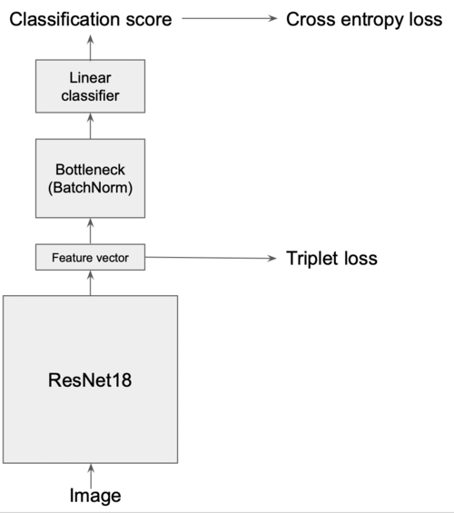

```python
def weights_init_kaiming(m):
    classname = m.__class__.__name__
    if m.affine:
        nn.init.constant_(m.weight, 1.0)
        nn.init.constant_(m.bias, 0.0)


def weights_init_classifier(m):
    classname = m.__class__.__name__
    if classname.find("Linear") != -1:
        nn.init.normal_(m.weight, std=0.001)
        if m.bias:
            nn.init.constant_(m.bias, 0.0)


class TripletNetwork(nn.Module):
    # implement the triplet network
    def __init__(self, num_classes):
        super(TripletNetwork, self).__init__()
        resnet = torchvision.models.resnet18(pretrained=False)
        self.conv = torch.nn.Sequential(*(list(resnet.children())[:-1]))
        self.global_pool = nn.AdaptiveAvgPool2d(1)

        self.bottleneck = nn.BatchNorm1d(512)
        # no shift
        self.bottleneck.bias.requires_grad_(False)

        self.classifier = nn.Linear(512, num_classes, bias=False)

        self.bottleneck.apply(weights_init_kaiming)
        self.classifier.apply(weights_init_classifier)

    def extract_feature(self, x):
        x = self.conv(x)

        global_feat = self.global_pool(x)
        global_feat = global_feat.view(global_feat.size(0), -1)

        feat = self.bottleneck(global_feat)

        if not self.training:
            return feat

        cls_score = self.classifier(feat)

        return global_feat, cls_score

    def forward(self, anchor_img, pos_img, neg_img):
        anchor_feat, anchor_score = self.extract_feature(anchor_img)
        pos_feat, pos_score = self.extract_feature(pos_img)
        neg_feat, neg_score = self.extract_feature(neg_img)

        feats = torch.cat((anchor_feat, pos_feat, neg_feat))
        scores = torch.cat((anchor_score, pos_score, neg_score))
        return anchor_feat, pos_feat, neg_feat, feats, scores
```

## 2.3 Triplet loss

Triplet loss uses the same concept as contrastive loss that is the anchor image will pull the positive one closer and push the negative one further than the constant margin away. Hence, we have sampled three images to compute it. The three images consist of:

1. an anchor image = an initial image
2. a positive image = the image having the same identity as the anchor image
3. a negative image = the image having a different identity from the anchor image

The triplet loss is mathematically defined as:

$L_{Triplet} = max(0, m + d(r_a, r_p) - d(r_a, r_n))$

where

- $d(r_1, r_2)$ = euclidean distance between $r_1$ and $r_2$
- $m$ = margin
- $r_a$ = the feature vector of the anchor image
- $r_p$ = the feature vector of the positive image
- $r_n$ = the feature vector of the negative image

The loss aims to minimize $d(r_a, r_p)$ while maximizing $d(r_a, r_n)$ at the same time.

The margin $m$ is used to prevent the loss from collapsing to a trivial solution. For instance, when $m = 0$, the model could achieve $L = 0$ just by exploiting the objective by setting $r_a = r_p = r_n$, and the model, as a result, would learn nothing useful.

```python
class TripletLoss(nn.Module):
    # implement the triplet loss
    def __init__(self, margin=2.0):
        super(TripletLoss, self).__init__()
        self.margin = margin
        self.euclidean_dist_fn = nn.PairwiseDistance(p=2)

    def forward(self, anchor_img, pos_img, neg_img):
        pos_dist = self.euclidean_dist_fn(anchor_img, pos_img)
        neg_dist = self.euclidean_dist_fn(anchor_img, neg_img)
        return torch.mean(torch.relu(pos_dist - neg_dist + self.margin))
```

## 2.4 Center loss

Reference: https://ydwen.github.io/papers/WenECCV16.pdf

**Definition**

Centroid: a representative of each class. There are several ways to select a representative, one way to do this is to take an average on those embeddings.

**Concept**

Center loss enforces the intra-class feature vectors to come closer to the centroid of their class so that all feature vectors of the same identity are clustered around a single centroid. Since the model is updated after each iteration, the centroids should also be updated accordingly. However, re-calculating the centroids by averaging the feature vectors for each class every iteration is computational-extensive on a large scale. Therefore, the centroid is instead learned from the representative of each class from the sampled data.

**Implementation detail**

In `__init__` method

1. For simplicity, we will store the centroids in the class `CenterLoss`. Therefore, you have to initialize the centroids as a random tensor with the size of `(num_classes, feature_dimension)`. The tensor has to be set with `nn.Paramater` so that the gradient could be calculated (ref: https://pytorch.org/docs/stable/generated/torch.nn.parameter.Parameter.html).

In the `forward` method

1. Calculate the distance between the feature vector and its center with a squared Euclidean distance
2. Clip the value in each element to be not greater than 1e+12, not lower than 1e-12, and sum them
3. Normalize the loss with its batch size

**Center loss equation**

$L_{Center} = \frac{1}{B}\sum_{j=1}^{B}||f_{j} - c_{y_j}||_2^2$

where

- $f_{j}$ = a feature vector before fed into the bottleneck at index $j$
- $c_{y_j}$ = a center of the class corresponded to the index $j$
- B = batch size

The center loss minimized the distance between the feature vector and the centroid of the corresponded identity.

**Note**

1. At `__init__` method in step 1. Do not forget to transfer the parameters to GPU with `.cuda()` otherwise, it will not utilize GPU on this part.
2. Clip the magnitude of the loss at the final stage before updating both upper bound and lower bound to avoid vanishing / exploding gradients.

**Hint**

1. In step 2 of the `forward` method, you should use `torch.clamp` (ref: https://pytorch.org/docs/stable/generated/torch.clamp.html) to clip the lower bound and the upper bound as you want.

```python
class CenterLoss(nn.Module):
    def __init__(self, num_classes, feat_dim):
        super(CenterLoss, self).__init__()
        self.device = "cuda" if torch.cuda.is_available() else "cpu"
        self.num_classes = num_classes
        self.feat_dim = feat_dim
        self.centers = nn.Parameter(
            torch.randn(self.num_classes, self.feat_dim).to(self.device)
        )

    def forward(self, x, labels):
        batch_size = x.size(0)
        # compute squared euclidean distance
        distmat = (
            torch.pow(x, 2)
            .sum(dim=1, keepdim=True)
            .expand(batch_size, self.num_classes)
            + torch.pow(self.centers, 2)
            .sum(dim=1, keepdim=True)
            .expand(self.num_classes, batch_size)
            .t()
        )
        distmat.addmm_(1, -2, x, self.centers.t())

        classes = torch.arange(self.num_classes).long().to(self.device)
        labels = labels.unsqueeze(1).expand(batch_size, self.num_classes)
        mask = labels.eq(classes.expand(batch_size, self.num_classes))

        dist = distmat * mask.float()
        loss = dist.clamp(min=1e-12, max=1e12).sum() / batch_size
        return loss
```

```python
center_loss_fn = CenterLoss(80, 512)
feats = torch.randn(32, 512).cuda()
labels = torch.randn(32).cuda()
center_loss_fn(feats, labels)
```

```
tensor(8.0000e-11, device='cuda:0', grad_fn=<DivBackward0>)
```

## 2.5 Declare model, criterions, optimizers, hyparameters and scheduler

```python
# for triplet loss
triplet_margin = 3.0

# get the number of classes to construct a linear classifier and the parameters in center loss
num_classes = len(set(train_triplet_dataset.labels))
print(f"num_classes = {num_classes}")

# declare the triplet model and the triplet criterion
triplet_model = TripletNetwork(num_classes)
triplet_criterion = TripletLoss(margin=triplet_margin)

triplet_optimizer = optim.Adam(triplet_model.parameters(), lr=5e-4)
triplet_scheduler = optim.lr_scheduler.ReduceLROnPlateau(
    triplet_optimizer, "min", patience=4, factor=0.1, min_lr=1e-8
)

# declare cross entropy loss
crossentropy_criterion = nn.CrossEntropyLoss()

# For center loss
# declare the center criterion
triplet_center_criterion = CenterLoss(num_classes, 512)

triplet_center_optimizer = optim.Adam(triplet_center_criterion.parameters(), lr=0.5)
triplet_center_loss_weight = 5e-2
```

```
num_classes = 80
```

## 2.6 Training loop

The figure below shows how the center loss is updated in the original paper. $L_s$ $L_c$, $W$, $\theta_c$ and $c_j$ stand for classification loss, center loss, classification head's weight, CNN weight, and centroid of the class $j$, respectively. Line 6 shows how centroids are updated.

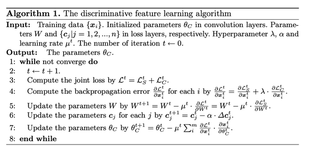

**Joint loss equation**

$L_{Joint} = L_{ID} + L_{Triplet} + \beta L_{Center}$

where

- $L_{Joint}$ = joint loss
- $L_{ID}$ = identity loss (cross entropy loss in this implementation)
- $L_{Triplet}$ = triplet loss
- $L_{Center}$ = center loss
- $\beta$ = center loss weights (affects only the triplet network, not center update)

The training procedure of the triplet network consists of the following steps:

1. Forward pass the `anchor_img`
2. Forward pass the `positive_img`
3. Forward pass the `negative_img`
4. Calculate the distance between the feature vectors of `anchor_img`, `positive_img` and `negative_img` and calculate a triplet loss ($L_{Triplet}$).
5. Calculate the classification loss ($L_{ID}$).
6. Calculate the center loss ($L_{Center}$).
7. Scale the center loss with the predetermined weight ($\beta$) (only used to update the triplet network not to update the centroids).
8. Sum the losses from steps 4-7 and update the triplet network. (Line 3-5)
9. Rescale the gradients with $\frac{1}{\beta}$ at the loss in step 7 and update the centroids. (Line 6-7)
10. Repeat steps 1-9 till converge

As you would notice, steps 1- 3 share the same model weight for feature extraction. Thus, the word "triplet" in triplet loss originates in a similar fashion as the "Siamese twins" but this loss function utilizes three feature vectors simultaneously instead of two.

**Hint**

1. At the gradient rescaling for the centroids, we should iterate parameters in center loss first with `.parameters()` and adjust the property of each parameter with `.grad.data`

```python
num_epochs = 20
device = "cuda" if torch.cuda.is_available() else "cpu"

os.makedirs("weights", exist_ok=True)
best_weights_path = "weights/best_triplet_weights.pth"
triplet_model.to(device)
min_val_loss = float("inf")

train_losses = []
train_triplet_losses = []
train_crossentropy_losses = []
train_center_losses = []

val_losses = []
val_triplet_losses = []

for epoch in tqdm(range(num_epochs)):
    triplet_model.train()
    total_train_loss = 0
    total_train_triplet_loss = 0
    total_train_crossentropy_loss = 0
    total_train_center_loss = 0
    for anchor_img, pos_img, neg_img, anchor_label, pos_label, neg_label in tqdm(
        train_triplet_dataloader
    ):

        # feed data to the triplet model and compute triplet loss
        anchor_img, pos_img, neg_img = (
            anchor_img.to(device),
            pos_img.to(device),
            neg_img.to(device),
        )
        anchor_label, pos_label, neg_label = (
            anchor_label.to(device),
            pos_label.to(device),
            neg_label.to(device),
        )
        labels = torch.cat((anchor_label, pos_label, neg_label))

        anchor_feat, pos_feat, neg_feat, feats, scores = triplet_model(
            anchor_img, pos_img, neg_img
        )
        train_triplet_loss = triplet_criterion(anchor_feat, pos_feat, neg_feat)

        # compute cross entropy loss
        train_crossentropy_loss = crossentropy_criterion(scores, labels)

        # compute center loss
        train_center_loss = triplet_center_loss_weight * triplet_center_criterion(
            feats, labels
        )

        train_loss = train_triplet_loss + train_crossentropy_loss + train_center_loss
        total_train_loss += train_loss.item()
        total_train_triplet_loss += train_triplet_loss.item()
        total_train_crossentropy_loss += train_crossentropy_loss.item()
        total_train_center_loss += train_center_loss.item()

        # set zero gradients at two optimizers
        triplet_optimizer.zero_grad()
        triplet_center_optimizer.zero_grad()

        # back propagate at triplet network and step the main optimizer
        train_loss.backward()
        triplet_optimizer.step()

        # rescale gradients of centers because `triplet_center_loss_weight` should not affect to learning the centers
        # and step the center optimizer
        for param in triplet_center_criterion.parameters():
            param.grad.data *= 1.0 / triplet_center_loss_weight
        triplet_center_optimizer.step()

    current_train_loss = total_train_loss / len(train_triplet_dataloader)
    current_train_triplet_loss = total_train_triplet_loss / len(
        train_triplet_dataloader
    )
    current_train_crossentropy_loss = total_train_crossentropy_loss / len(
        train_triplet_dataloader
    )
    current_train_center_loss = total_train_center_loss / len(train_triplet_dataloader)
    train_losses.append(current_train_loss)
    train_triplet_losses.append(current_train_triplet_loss)
    train_crossentropy_losses.append(current_train_crossentropy_loss)
    train_center_losses.append(current_train_center_loss)

    total_val_loss = 0
    total_val_triplet_loss = 0
    triplet_model.eval()
    for val_anchor_img, val_pos_img, val_neg_img, _, _, _ in val_triplet_dataloader:

        # feed data to the triplet model and compute triplet loss
        val_anchor_img, val_pos_img, val_neg_img = (
            val_anchor_img.to(device),
            val_pos_img.to(device),
            val_neg_img.to(device),
        )
        with torch.no_grad():
            val_anchor_feat = triplet_model.extract_feature(val_anchor_img)
            val_pos_feat = triplet_model.extract_feature(val_pos_img)
            val_neg_feat = triplet_model.extract_feature(val_neg_img)
            val_triplet_loss = triplet_criterion(
                val_anchor_feat, val_pos_feat, val_neg_feat
            )

        val_loss = val_triplet_loss
        total_val_loss += val_loss.item()
        total_val_triplet_loss += val_triplet_loss.item()
    current_val_loss = total_val_loss / len(val_triplet_dataloader)
    current_val_triplet_loss = total_val_triplet_loss / len(val_triplet_dataloader)
    val_losses.append(current_val_loss)
    val_triplet_losses.append(current_val_triplet_loss)

    if current_val_loss < min_val_loss:
        min_val_loss = current_val_loss
        torch.save(triplet_model.state_dict(), best_weights_path)
    print(
        f'Epoch {epoch+1} - Train loss = {current_train_loss:.4f} - Train triplet loss = {current_train_triplet_loss:.4f} - Train crossentropy loss = {current_train_crossentropy_loss:.4f}  - Train center loss = {current_train_center_loss:.4f} - Val loss = {current_val_loss:.4f} - Val triplet loss = {current_val_triplet_loss:.4f} - best min_val_loss = {min_val_loss:.4f} - lr = {triplet_optimizer.param_groups[0]["lr"]:.8f}'
    )
    triplet_scheduler.step(current_val_loss)
```

```
Epoch 1 - Train loss = 11.0346 - Train triplet loss = 2.2516 - Train crossentropy loss = 3.8206  - Train center loss = 4.9624 - Val loss = 2.0967 - Val triplet loss = 2.0967 - best min_val_loss = 2.0967 - lr = 0.00050000
```

```
Epoch 2 - Train loss = 7.2779 - Train triplet loss = 1.7405 - Train crossentropy loss = 2.7781  - Train center loss = 2.7593 - Val loss = 1.2788 - Val triplet loss = 1.2788 - best min_val_loss = 1.2788 - lr = 0.00050000
```

```
Epoch 3 - Train loss = 6.5910 - Train triplet loss = 1.3164 - Train crossentropy loss = 1.9013  - Train center loss = 3.3733 - Val loss = 0.9544 - Val triplet loss = 0.9544 - best min_val_loss = 0.9544 - lr = 0.00050000
```

```
Epoch 4 - Train loss = 5.3633 - Train triplet loss = 1.2036 - Train crossentropy loss = 1.2312  - Train center loss = 2.9284 - Val loss = 0.6782 - Val triplet loss = 0.6782 - best min_val_loss = 0.6782 - lr = 0.00050000
```

```
Epoch 5 - Train loss = 5.6049 - Train triplet loss = 0.9512 - Train crossentropy loss = 0.7218  - Train center loss = 3.9318 - Val loss = 0.7999 - Val triplet loss = 0.7999 - best min_val_loss = 0.6782 - lr = 0.00050000
```

```
Epoch 6 - Train loss = 4.6572 - Train triplet loss = 0.9125 - Train crossentropy loss = 0.4834  - Train center loss = 3.2612 - Val loss = 0.9410 - Val triplet loss = 0.9410 - best min_val_loss = 0.6782 - lr = 0.00050000
```

```
Epoch 7 - Train loss = 4.1720 - Train triplet loss = 0.7144 - Train crossentropy loss = 0.2933  - Train center loss = 3.1644 - Val loss = 0.9422 - Val triplet loss = 0.9422 - best min_val_loss = 0.6782 - lr = 0.00050000
```

```
Epoch 8 - Train loss = 4.3852 - Train triplet loss = 0.6381 - Train crossentropy loss = 0.1771  - Train center loss = 3.5699 - Val loss = 1.0889 - Val triplet loss = 1.0889 - best min_val_loss = 0.6782 - lr = 0.00050000
```

```
Epoch 9 - Train loss = 4.4035 - Train triplet loss = 0.6213 - Train crossentropy loss = 0.1393  - Train center loss = 3.6429 - Val loss = 1.0388 - Val triplet loss = 1.0388 - best min_val_loss = 0.6782 - lr = 0.00050000
```

```
Epoch 10 - Train loss = 3.6412 - Train triplet loss = 0.4387 - Train crossentropy loss = 0.0512  - Train center loss = 3.1513 - Val loss = 0.7098 - Val triplet loss = 0.7098 - best min_val_loss = 0.6782 - lr = 0.00005000
```

```
Epoch 11 - Train loss = 4.6735 - Train triplet loss = 0.3263 - Train crossentropy loss = 0.0290  - Train center loss = 4.3182 - Val loss = 0.7936 - Val triplet loss = 0.7936 - best min_val_loss = 0.6782 - lr = 0.00005000
```

```
Epoch 12 - Train loss = 3.5012 - Train triplet loss = 0.3054 - Train crossentropy loss = 0.0227  - Train center loss = 3.1731 - Val loss = 0.7753 - Val triplet loss = 0.7753 - best min_val_loss = 0.6782 - lr = 0.00005000
```

```
Epoch 13 - Train loss = 3.5312 - Train triplet loss = 0.2669 - Train crossentropy loss = 0.0197  - Train center loss = 3.2446 - Val loss = 0.7331 - Val triplet loss = 0.7331 - best min_val_loss = 0.6782 - lr = 0.00005000
```

```
Epoch 14 - Train loss = 4.1395 - Train triplet loss = 0.2424 - Train crossentropy loss = 0.0172  - Train center loss = 3.8800 - Val loss = 0.7180 - Val triplet loss = 0.7180 - best min_val_loss = 0.6782 - lr = 0.00005000
```

```
Epoch 15 - Train loss = 3.0232 - Train triplet loss = 0.2472 - Train crossentropy loss = 0.0151  - Train center loss = 2.7609 - Val loss = 0.6653 - Val triplet loss = 0.6653 - best min_val_loss = 0.6653 - lr = 0.00000500
```

```
Epoch 16 - Train loss = 3.3044 - Train triplet loss = 0.2158 - Train crossentropy loss = 0.0123  - Train center loss = 3.0763 - Val loss = 0.9082 - Val triplet loss = 0.9082 - best min_val_loss = 0.6653 - lr = 0.00000500
```

```
Epoch 17 - Train loss = 4.5525 - Train triplet loss = 0.2266 - Train crossentropy loss = 0.0133  - Train center loss = 4.3126 - Val loss = 0.7732 - Val triplet loss = 0.7732 - best min_val_loss = 0.6653 - lr = 0.00000500
```

```
Epoch 18 - Train loss = 3.1909 - Train triplet loss = 0.2080 - Train crossentropy loss = 0.0174  - Train center loss = 2.9655 - Val loss = 0.6944 - Val triplet loss = 0.6944 - best min_val_loss = 0.6653 - lr = 0.00000500
```

```
Epoch 19 - Train loss = 3.6640 - Train triplet loss = 0.2256 - Train crossentropy loss = 0.0130  - Train center loss = 3.4254 - Val loss = 0.8703 - Val triplet loss = 0.8703 - best min_val_loss = 0.6653 - lr = 0.00000500
```

```
Epoch 20 - Train loss = 5.0857 - Train triplet loss = 0.2087 - Train crossentropy loss = 0.0142  - Train center loss = 4.8627 - Val loss = 0.7466 - Val triplet loss = 0.7466 - best min_val_loss = 0.6653 - lr = 0.00000500
```

## 2.7 Visualization

The visualization below displays an anchor, positive, and negative image and their respective distance.

```
Clipping input data to the valid range for imshow with RGB data ([0..1] for floats or [0..255] for integers). Got range [0.0..1.1742941].
```

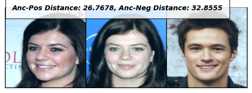

```
Clipping input data to the valid range for imshow with RGB data ([0..1] for floats or [0..255] for integers). Got range [0.0..1.1742941].
```

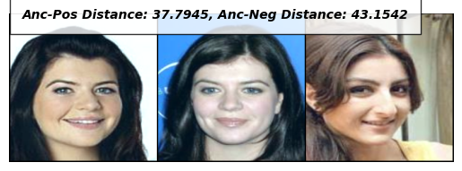

```
Clipping input data to the valid range for imshow with RGB data ([0..1] for floats or [0..255] for integers). Got range [0.0..1.1742941].
```

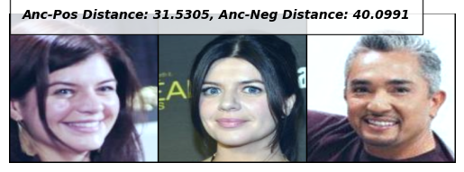

```
Clipping input data to the valid range for imshow with RGB data ([0..1] for floats or [0..255] for integers). Got range [0.0..1.1659949].
```

[figure not shown]

```
Clipping input data to the valid range for imshow with RGB data ([0..1] for floats or [0..255] for integers). Got range [0.0..1.1535463].
```

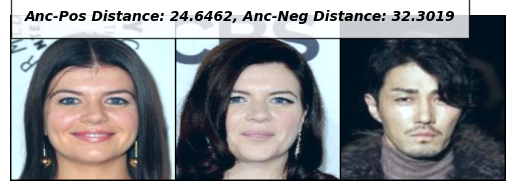

```
Clipping input data to the valid range for imshow with RGB data ([0..1] for floats or [0..255] for integers). Got range [0.0..1.1742941].
```

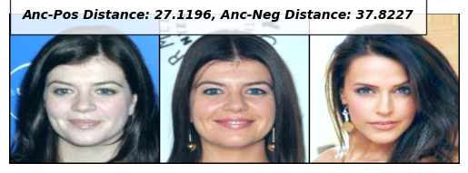

```
Clipping input data to the valid range for imshow with RGB data ([0..1] for floats or [0..255] for integers). Got range [0.0..1.1742941].
```

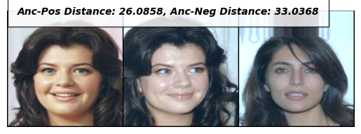

```
Clipping input data to the valid range for imshow with RGB data ([0..1] for floats or [0..255] for integers). Got range [0.0..1.1701446].
```

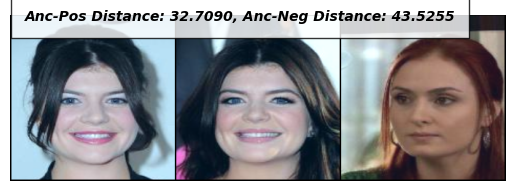

```
Clipping input data to the valid range for imshow with RGB data ([0..1] for floats or [0..255] for integers). Got range [0.0..1.1162004].
```

[figure not shown]

```
Clipping input data to the valid range for imshow with RGB data ([0..1] for floats or [0..255] for integers). Got range [0.0..1.1410978].
```

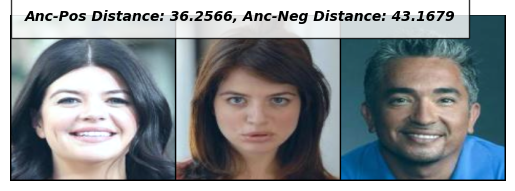

```
Clipping input data to the valid range for imshow with RGB data ([0..1] for floats or [0..255] for integers). Got range [0.0..1.1742941].
```

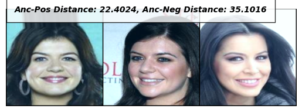

```
Clipping input data to the valid range for imshow with RGB data ([0..1] for floats or [0..255] for integers). Got range [0.0..1.0931027].
```

[figure not shown]

```
Clipping input data to the valid range for imshow with RGB data ([0..1] for floats or [0..255] for integers). Got range [0.0..1.1701446].
```

[4 more figures not shown]

```python
# Showing images
def imshow(img, text=None):
    npimg = img.numpy()
    plt.axis("off")
    if text:
        plt.text(
            20,
            8,
            text,
            style="italic",
            fontweight="bold",
            bbox={"facecolor": "white", "alpha": 0.8, "pad": 10},
        )

    plt.imshow(np.transpose(npimg, (1, 2, 0)))
    plt.show()


best_weights_path = "weights/best_triplet_weights.pth"
triplet_model.to(device)
triplet_model.load_state_dict(torch.load(best_weights_path))
triplet_model.eval()

test_anchor_imgs, test_pos_imgs, test_neg_imgs, test_anchor_ids, _, _ = next(
    iter(test_triplet_dataloader)
)
test_anchor_imgs, test_pos_imgs, test_neg_imgs = (
    test_anchor_imgs.to(device),
    test_pos_imgs.to(device),
    test_neg_imgs.to(device),
)
with torch.no_grad():
    test_anchor_feats = triplet_model.extract_feature(test_anchor_imgs)
    test_pos_feats = triplet_model.extract_feature(test_pos_imgs)
    test_neg_feats = triplet_model.extract_feature(test_neg_imgs)


class UnNormalize(object):
    def __init__(self, mean, std):
        self.mean = mean
        self.std = std

    def __call__(self, tensor):
        """
        Args:
            tensor (Tensor): Tensor image of size (C, H, W) to be normalized.
        Returns:
            Tensor: Normalized image.
        """
        for t, m, s in zip(tensor, self.mean, self.std):
            t.mul_(s).add_(m)
            # The normalize code -> t.sub_(m).div_(s)
        return tensor


unnormalizer = UnNormalize(mean=[0.5319, 0.4399, 0.3929], std=[0.3076, 0.2898, 0.2907])

zip_test_data = zip(
    test_anchor_feats,
    test_pos_feats,
    test_neg_feats,
    test_anchor_imgs,
    test_pos_imgs,
    test_neg_imgs,
)
for (
    test_anchor_feat,
    test_pos_feat,
    test_neg_feat,
    test_anchor_img,
    test_pos_img,
    test_neg_img,
) in zip_test_data:
    test_anchor_img = unnormalizer(test_anchor_img.detach().cpu().unsqueeze(0))
    test_pos_img = unnormalizer(test_pos_img.detach().cpu().unsqueeze(0))
    test_neg_img = unnormalizer(test_neg_img.detach().cpu().unsqueeze(0))
    concatenated = torch.cat((test_anchor_img, test_pos_img, test_neg_img), 0)
    anc_pos_distance = F.pairwise_distance(
        test_anchor_feat.unsqueeze(0), test_pos_feat.unsqueeze(0)
    )
    anc_neg_distance = F.pairwise_distance(
        test_anchor_feat.unsqueeze(0), test_neg_feat.unsqueeze(0)
    )
    imshow(
        torchvision.utils.make_grid(concatenated),
        f"Anc-Pos Distance: {anc_pos_distance.item():.4f}, Anc-Neg Distance: {anc_neg_distance.item():.4f}",
    )
```